# Examples of Use

## Downloading

1. Download splot.RData to your current working directory.
2. Load the data:

```r
load("splot.RData")
```

Note: this file also includes *Spalette* colour schemes. To use the Spalette palette on its own, download spalette.RData.

## Comparisons to Base Plots

### Simple, Simple Plots: little to no customization

**Basic 1:** y vector left NULL  
**Basic 2:** x and y vectors given

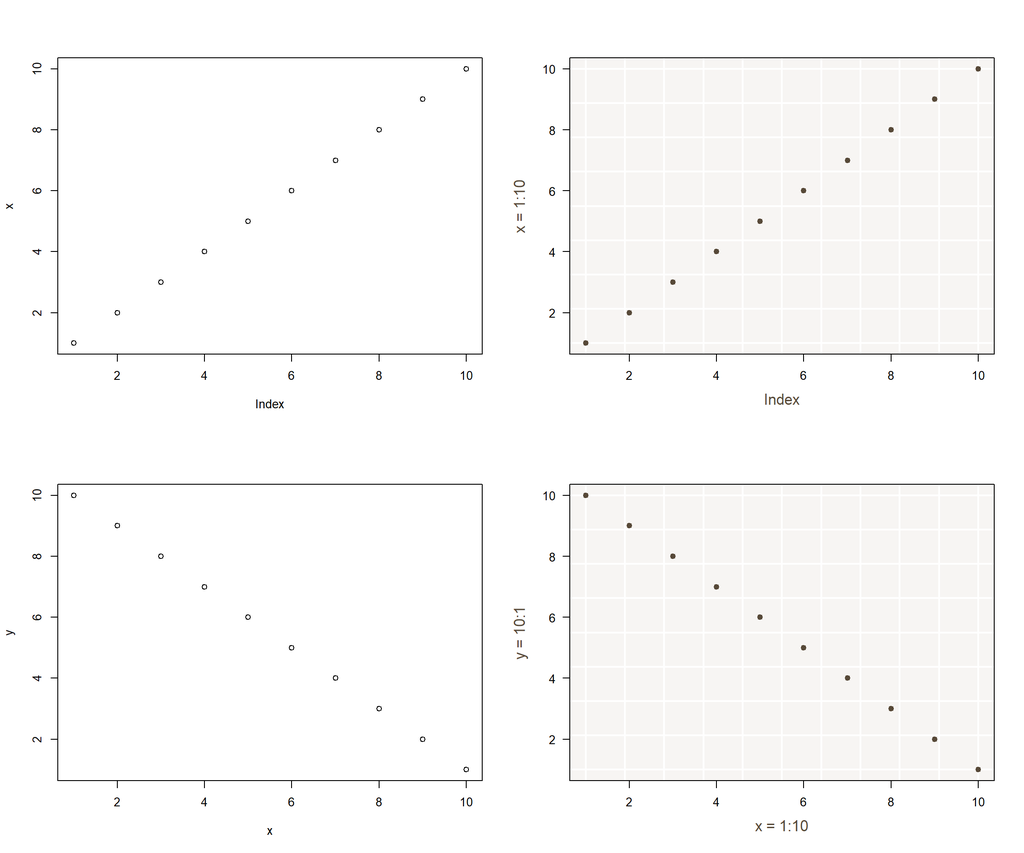

| Maintained Attributes |
| --- |
| spacing of data points, axis limits, etc. |
| some axis naming conventions (see below) |

| Changes | Description | How to Revert |
| --- | --- | --- |
| Foreground Colour | Data points and axis labels are now `skrown$B2` (the darkest brown in Spalette). | `col = "black"` |
| Point Character | Points are now solid by default (`pch = 19`) | `pch = 1` |
| Background Colour | the background of the plot window is now `skrown$smoke` | `colr = "white"` |
| Orientation Lines | There are now gridlines for quick visual alignment of the data to each axis, similar to ggplot(). | `skor = FALSE` |
| Tick Label Orientation | The y-axis tick labels are now upright, similar to ggplot(). | `las = 0` |
| Axis Label Names | By default, the name of each variable is given, *along with its de-parsed value.* | `labs = 0` or `labs = 1` |
| Axis Label Spacing | x-axis label sits a bit higher, font a tiny bit bigger at `cex = 1.05"` | `xlab = ""` (add your own, manually.) |

```r
# Setup
par(mfrow= c(2,2))

# Vectors to plot
x <- 1:10
y <- 10:1

# --- Basic 1
plot (x)
splot(x)

# --- Basic 2
plot (x, y)
splot(x, y)
```

#### NOTES

The default Splot background colour is roughly similar to the default *chunk* background colour knit by RMarkdown files, whether to pdf or html. (I don’t use Word, sorry.) I find that this results in a nicer distribution of shading across the knitted document. I say “roughly similar” because it’s more saturated, with a faint orange hue, as all grey-scales are in Skye’s world.

- For a subtler look, try specifying the parameter `colr = skrown$salt`.
- Another subtle look is to set `skorcol = skrown$salt` for less contrast between the background and its grid lines.

The axis labels can be a bit verbose, but are mostly similar to plot.default(). I like the extra detail, but if you want to clean it up:

- `labs = 0` removes all axis labels so that you can add your own “in post”
- `labs = 1` eliminates the de-parsing component, so you get back whatever you put in for `x` and `y`, verbatim.

- You can revert this by setting `ylab = ""` and adding your own label, manually, if you really need to.
- Admittedly, if your figure margins or similar graphical parameters are real wonky, the label might not scale accordingly, so consider setting `labs = 0` if your axis labels are giving you grief.

### Simple Plots: Minor customizations

**Mod 1:** Titles included  
**Mod 2:** Subtitles  
**Mod 3:** Plot type changed  
**Mod 4:** Axis limits modified

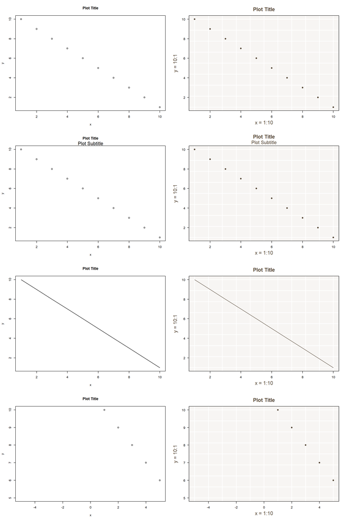

| Maintained Attributes |
| --- |
| spacing of axis limits |
| Line types. Note that other types (“b”, “o”, “h”, etc.) are all supported by splot() |

| Changes | Description | How to Revert |
| --- | --- | --- |
| Title Size/Colour | Title size is fixed, colour defaults to `skrown$B2`. | `coll = "black`, otherwise, add manually via `mtext` |
| Title Positioning | Title is raised slightly to make room for subtitle, *iff subtitle is non-empty.* Moreover, the *subtitle* sits higher than the default `mtext()` output. | Add subtitle manually via `mtext()` |
| Subtitle syntax | Subtitles are called by `splot()` directly, via the parameter `subb` | (omitted by default) |

```r
# Setup
par(mfrow= c(4,2))

# Vectors to plot
x <- 1:10
y <- 10:1

# --- Mod 1
plot (x, y, main = "Plot Title")
splot(x, y, main = "Plot Title")

# --- Mod 2
plot (x, y, main = "Plot Title"); mtext("Plot Subtitle")
splot(x, y, main = "Plot Title", subb = "Plot Subtitle")

# --- Mod 3
plot (x, y, main = "Plot Title", type = "l")
splot(x, y, main = "Plot Title", type = "l")

# --- Mod 4
plot (x, y, main = "Plot Title", xlim = c(-5,5), ylim = c(5,10))
splot(x, y, main = "Plot Title", xlim = c(-5,5), ylim = c(5,10))
```

Changing the value of `coll` will affect all margin text. That is, titles *and* axis labels. If you want to colour these values independently, you may use `mtext()`, OR, my function `slab()`. The latter will preserve all other text attributes as per the `splot()` output.

### Plots: More customizations

```r
# splot(x,y, log = "y")
```